# Project 2: Investigate a Dataset

1. Introduction
2. Data Wrangling
3. Exploratory Data Analysis
4. Assessment of the Claims
5. Conclusions

## 1 Introduction

The aim of this project is to assess whether some of the following statements are supported by evidence from Gapminder's datasets or not.

> "*Transport is Europe's biggest source of CO_2, responsible for the emission of over a quarter of all greenhouse gases. Transport emissions have increased by a quarter since 1990 and are continuing to rise with 2017 oil consumption in the EU increasing at its fastest pace since 2001. Unless transport emissions are brought under control national 2030 climate goals will be missed. To meet the 2050 Paris climate commitments cars and vans must be entirely decarbonised. This requires ending sales of cars with an internal combustion engine by 2035. Such a transformation requires wholesale changes, not only to vehicles but also how they are owned, taxed and driven.*"

Source: [PDF](https://www.transportenvironment.org/sites/te/files/publications/2018_04_CO2_emissions_cars_The_facts_report_final_0_0.pdf), page 2 <sup>1</sup>.

From this text, we have selected the following claims:

- **Claim 1** - *Transport is Europe's biggest source of $CO_2$*;
- **Claim 2** - *Transport emissions have increased by a quarter since 1990*;
- **Claim 3** - *Transport is responsible for the emission of over a quarter of all greenhouse gases*.

### 1.1 Structure of the Argumentation

#### Claim 1 - Transport is Europe's biggest source of $CO_2$

Basically, the object of interest is the ratio of $CO_2$ emission from the transport sector to the total $CO_2$ emission in Europe, per year.

On the Gapminder website, we can find the following datasets:

| Nr. | Dataset Name | File Name |
| --- | --- | --- |
| 1 | CO2 emissions from transport (% of total fuel combustion) | en_co2_tran_zs.csv |
| 2 | CO2 emissions from electricity and heat production, total (% of total fuel combustion) | en_co2_etot_zs.csv |
| 3 | CO2 emissions from manufacturing industries and construction (% of total fuel combustion) | en_co2_manf_zs.csv |
| 4 | CO2 emissions from residential buildings and commercial and public services (% of total fuel combustion) | en_co2_bldg_zs.csv |
| 5 | CO2 emissions from other sectors, excluding residential buildings and commercial and public services (% of total fuel combustion) | en_co2_othx_zs.csv |

We will extract the data for EU countries and compare the mean share of $CO_2$ emission per sector.

#### Claim 2 - Transport emissions have increased by a quarter since 1990

Gapminder offers a dataset of yearly $CO_2$ emissions per country (in kt).

| Nr. | Dataset Name | File Name |
| --- | --- | --- |
| 1 | CO2 emissions (1000 tonnes) | yearly_co2_emissions_1000_tonnes.csv |

We will calculate the sum of yearly $CO_2$ emission in the EU for years from 1990 to the most recent, common year available.

Thereafter, we will apply the shares of $CO_2$ emission from the transportation sector (calculated as mentioned in 'Claim 1') in order to obtain the level value for each reference year and compute the increase from 1990.

#### Claim 3 - Transport is responsible for the emission of over a quarter of all greenhouse gases

A dataset of total greenhouse gas emissions ($CO_2$ equivalent) is also available (same scale, kt):

| Nr. | Dataset Name | File Name |
| --- | --- | --- |
| 1 | Total greenhouse gas emissions (kt of CO2 equivalent) | en_atm_ghgt_kt_ce.csv |

We will use the results of 'Claim 2' and compare the $CO_2$ emissions from the transportation sector to the $CO_2$-equivalent emissions of all greenouse gasses.

### 1.2 Packages

```python
from collections import OrderedDict
from matplotlib import pyplot as plt

import numpy  as np,  \
       os,            \
       pandas as pd,  \
       seaborn as sns

%matplotlib inline
```

## 2 Data Wrangling

In this section, we will load in the data, check for cleanliness, and then trim and clean the datasets for analysis.

### 2.1 Data Import

We will import data into an ordered dictionary. On top of usual dictionary pros (key call, all datasets within an unique objec, etc...), an ordered dictionay allows us here to reorder each entry in it.

**Note**: here we assume that this notebook runs in the same directory where datasets are stored. If this is not the case, please updaet the 'path' variable.

```python
path = os.getcwd()

DS=OrderedDict()
for entry in os.listdir(path):
    if entry[-4:] == '.csv':
        #print(entry)
        if 'etot' in entry:
            DS['elect']=pd.read_csv(entry)
        if 'manf' in entry:
            DS['manuf']=pd.read_csv(entry)
        if 'othx' in entry:
            DS['other']=pd.read_csv(entry)
        if 'bldg' in entry:
            DS['build']=pd.read_csv(entry)
        if 'tran' in entry:
            DS['trans']=pd.read_csv(entry)
        if 'co2_emissions' in entry:
            DS['co2']=pd.read_csv(entry)
        if 'atm_ghgt' in entry:
            DS['ghg']=pd.read_csv(entry)
#we want the co2 and ghg DFs in the last two positions.
DS.move_to_end('co2')
DS.move_to_end('ghg')
#DS.keys()

#Ref.: https://pymotw.com/3/collections/ordereddict.html
```

#### Data Overview

Note: in python 3.x we cannot use DS.items(0) to call the first element added to the dict.

Instead, we have to wrap DS.items() into a list. This list contains tuples of key and value. So, we need to call the value in that tuple in order to handle the dataframe object ([link](https://stackoverflow.com/questions/10058140/accessing-items-in-an-collections-ordereddict-by-index)).

E.g.:

```python
type(list(DS.items())[0])
```

```
tuple
```

```python
#key
list(DS.items())[0][0]
```

```
'trans'
```

```python
#value
type(list(DS.items())[0][1])
```

```
pandas.core.frame.DataFrame
```

```python
list(DS.items())[0][1].head()
```

|  | country | 1960 | 1961 | 1962 | 1963 | 1964 | 1965 | 1966 | 1967 | 1968 | ... | 2005 | 2006 | 2007 | 2008 | 2009 | 2010 | 2011 | 2012 | 2013 | 2014 |
| --- | --- | --- | --- | --- | --- | --- | --- | --- | --- | --- | --- | --- | --- | --- | --- | --- | --- | --- | --- | --- | --- |
| 0 | Albania | NaN | NaN | NaN | NaN | NaN | NaN | NaN | NaN | NaN | ... | 62.0 | 50.7 | 55.6 | 61.5 | 61.0 | 56.7 | 56.5 | 64.7 | 67.3 | 60.0 |
| 1 | Algeria | NaN | NaN | NaN | NaN | NaN | NaN | NaN | NaN | NaN | ... | 31.2 | 31.7 | 32.5 | 33.1 | 32.3 | 33.1 | 32.0 | 32.6 | 32.8 | 35.3 |
| 2 | Angola | NaN | NaN | NaN | NaN | NaN | NaN | NaN | NaN | NaN | ... | 39.8 | 39.5 | 40.0 | 43.7 | 41.1 | 42.4 | 44.1 | 44.5 | 45.1 | 44.0 |
| 3 | Argentina | NaN | NaN | NaN | NaN | NaN | NaN | NaN | NaN | NaN | ... | 26.5 | 26.3 | 25.6 | 25.5 | 24.0 | 25.0 | 27.2 | 26.3 | 25.3 | 24.2 |
| 4 | Armenia | NaN | NaN | NaN | NaN | NaN | NaN | NaN | NaN | NaN | ... | 16.2 | 15.9 | 22.1 | 23.9 | 26.7 | 31.1 | 27.6 | 23.9 | 24.4 | 27.8 |

5 rows × 56 columns

```python
list(DS.items())[0][1].info()
```

```
<class 'pandas.core.frame.DataFrame'>
RangeIndex: 138 entries, 0 to 137
Data columns (total 56 columns):
 #   Column   Non-Null Count  Dtype
---  ------   --------------  -----
 0   country  138 non-null    object
 1   1960     25 non-null     float64
 2   1961     25 non-null     float64
 3   1962     25 non-null     float64
 4   1963     25 non-null     float64
 5   1964     25 non-null     float64
 6   1965     26 non-null     float64
 7   1966     26 non-null     float64
 8   1967     26 non-null     float64
 9   1968     26 non-null     float64
```

[output cut: 48 more lines]

We can already see that many values are not available, especially for years up to 1970. From 1990 onwards, we have a good covreage. Missing entries are just 7 in 1990 and gradually decreasing up to 2011.

### 2.2 Data Selection

In this section, we will filter the datasets for EU countries and define a subset of reference years.

#### 2.2.1 Country Selection

Here below, we have composed a list of EU country names.

```python
EU_countries=[
'Austria',
'Belgium',
'Bulgaria',
'Croatia',
'Cyprus',
'Czechia',
'Denmark',
'Estonia',
'Finland',
'France',
'Germany',
'Greece',
'Hungary',
'Ireland',
'Italy',
'Latvia',
'Lithuania',
'Luxembourg',
'Malta',
'Netherlands',
'Poland',
'Portugal',
'Romania',
'Slovakia',
'Slovenia',
'Spain',
'Sweden'
]

# Source: https://europa.eu/european-union/about-eu/countries_en#tab-0-0
```

We can actually include the United Kingdom, for it was still part of the EU at the time.

```python
EU_countries.append('United Kingdom')
```

The new enrty will be appended in last position, which in this case coincides with its position by alphabetical order.

Now we can filter each dataset for the over-mentioned coutries. Before doing so, we will check first that all countries are available.

```python
len(EU_countries)
```

```
28
```

```python
def countryCountPerDS(DSDict, countryList):
    for dsName in list(DSDict.keys()):
        print(dsName,': ', DSDict[dsName].query('country in {}'.format(countryList)).shape[0])
```

```python
countryCountPerDS(DS, EU_countries)
```

```
trans :  26
elect :  26
other :  26
manuf :  26
build :  26
co2 :  26
ghg :  26
```

We can see that not every EU country has been detected. Let us find out what countries are not included.

```python
def countriesNotIncluded(DSDict, countryList):
    for dsName in list(DSDict.keys()):
        print(dsName+': ',list(set(countryList) - set(DSDict[dsName].query('country in {}'.format(countryList))['country'].to_list())))

# Ref.: https://stackoverflow.com/questions/3428536/python-list-subtraction-operation
```

```python
countriesNotIncluded(DS, EU_countries)
```

```
trans:  ['Czechia', 'Slovakia']
elect:  ['Czechia', 'Slovakia']
other:  ['Czechia', 'Slovakia']
manuf:  ['Czechia', 'Slovakia']
build:  ['Czechia', 'Slovakia']
co2:  ['Czechia', 'Slovakia']
ghg:  ['Czechia', 'Slovakia']
```

We can look for these two countries in EU_countries.

We will extract a country list from one of the dataframes, clear it from the entries already in our country list, and filter for those countries starting with 'C' or 'S'.

```python
detected_countries = DS['trans']['country'].to_list()
[country for country in detected_countries if (country not in EU_countries and country[0] in ['C', 'S'])]

# Ref.: https://stackoverflow.com/questions/6164443/iterating-through-a-list-with-an-if-statement
```

```
['Cambodia',
 'Cameroon',
 'Canada',
 'Chile',
 'China',
 'Colombia',
 'Congo, Dem. Rep.',
 'Congo, Rep.',
 'Costa Rica',
 "Cote d'Ivoire",
 'Cuba',
 'Czech Republic',
 'Saudi Arabia',
 'Senegal',
 'Serbia',
 'Singapore',
 'Slovak Republic',
 'South Africa',
 'South Korea',
 'South Sudan',
 'Sri Lanka',
 'Sudan',
 'Suriname',
 'Switzerland',
 'Syria']
```

All right: we have to rename those two entries.

We substitute then 'Czechia' with 'Czech Republic' and 'Slovakia' with 'Slovak Republic'.

```python
EU_countries[EU_countries.index('Czechia')]='Czech Republic'
EU_countries[EU_countries.index('Slovakia')]='Slovak Republic'
```

```python
## check:
#EU_countries
```

We can now retry the query.

```python
print('-> EU countries in datasets:')
countryCountPerDS(DS, EU_countries)
print('\n-> Missing countries:')
countriesNotIncluded(DS, EU_countries)
```

```
-> EU countries in datasets:
trans :  28
elect :  28
other :  28
manuf :  28
build :  28
co2 :  28
ghg :  28

-> Missing countries:
trans:  []
elect:  []
other:  []
manuf:  []
build:  []
co2:  []
ghg:  []
```

That looks fine. We can now overwrite the datasets.

```python
for dsName in list(DS.keys()):
    DS[dsName]=DS[dsName].query('country in {}'.format(EU_countries))
```

```python
# # quick overview:
#
# for i in range(len(DS)):
#     print('->', list(DS.items())[i][0],'\n',list(DS.items())[i][1].head(),'\n')
```

#### 2.2.2 Year Selection

In this section, we will trim our datasets, in order to have a common year range for our analysis.

The datasets include the following year ranges:

```python
for dsName in list(DS.keys()):
    print('Dataset: ', dsName, ' Start: ',list(DS[dsName])[1], 'Stop: ', list(DS[dsName])[-1])
```

```
Dataset:  trans  Start:  1960 Stop:  2014
Dataset:  elect  Start:  1960 Stop:  2014
Dataset:  other  Start:  1960 Stop:  2014
Dataset:  manuf  Start:  1960 Stop:  2014
Dataset:  build  Start:  1960 Stop:  2014
Dataset:  co2  Start:  1751 Stop:  2014
Dataset:  ghg  Start:  1970 Stop:  2012
```

The report mentioned in the introduciton has been published in 2018. However, our data range from year 1960 to 2014. The greenhouse-gas emissions dataset stops in 2012.

For 'Claim 2' mentions year 1990 as reference, we will limit each dataset to years from 1990 up to the most recent year. We will keep all the years in betweeen, so that we can inspect trends and make visualizations.

Therefore, we keep data from 1990 to 2014 in all datasets but 'ghg', where the last year will be 2012.

Befrore doing so, we have to create the column lists for the new dataframes. We will create a list of years, by leveraging on Numpy's arange function, add the country name in first position and trim a column list for the 'ghg' dataset, so that it ends with '2012'. Finally, we filter and apply the new column names to the original dataframes and overwrite them in our collection.

```python
# preparing column names

col=np.arange(start=1990, stop=2015).tolist()
col=[str(year) for year in col]
col.insert(0, 'country')
col_ghg=col[:-2]
cl=[col, col_ghg]

#print(col, '\n', col_ghg)

#Recall: 'stop' is not included!
# Ref.: https://numpy.org/doc/1.18/reference/generated/numpy.arange.html
```

```python
# filter and overwrite dataframes
for dsName in list(DS.keys()):
    if dsName == 'ghg':
        DS[dsName]=DS[dsName][cl[1]].reset_index(drop=True)
    else:
        DS[dsName]=DS[dsName][cl[0]].reset_index(drop=True)


#Note: inplace=True does not work here, for selection is a slice of DF -> it is not applied to the DF itself!
#Ref.: https://pandas.pydata.org/pandas-docs/stable/reference/api/pandas.DataFrame.reset_index.html
```

```python
# short overview

for i in range(len(DS)):
    print('->', list(DS.items())[i][0],'\n',list(DS.items())[i][1].head(),'\n')
```

```
-> trans
     country   1990   1991   1992   1993   1994   1995   1996   1997  1998  \
0   Austria  24.20  24.90  27.10  27.30  27.20  26.00  27.00  25.90  29.0
1   Belgium  19.10  18.60  19.70  20.70  20.40  20.50  20.10  20.80  20.8
2  Bulgaria   8.64   6.41   7.04   7.91   7.54   7.94   7.78   8.34  11.1
3   Croatia  17.50  19.50  19.50  19.60  22.00  22.10  23.70  24.00  23.0
4    Cyprus  29.80  26.10  27.40  26.70  26.70  28.90  28.20  28.70  28.4

   ...  2005  2006  2007  2008  2009  2010  2011  2012  2013  2014
0  ...  32.9  32.4  33.9  32.2  33.9  32.3  32.4  33.8  35.5  36.6
1  ...  24.1  24.3  25.2  26.2  27.5  25.2  28.4  26.7  26.1  28.6
2  ...  16.4  17.0  15.6  17.2  18.9  17.5  16.2  18.5  18.6  19.5
3  ...  27.3  28.9  28.9  30.0  31.7  31.9  31.8  33.6  35.2  36.6
4  ...  28.7  28.1  28.8  28.8  29.1  30.7  30.9  30.6  31.9  30.4

```

[output cut: 117 more lines]

The dataframes contain now just EU countries and yearly observations from 1990 to 2014 (or 2012).

### 2.3 Data Cleaning

#### 2.3.1 Check for Missing Values

We take a look at non-null value counts and Data types in each dataset.

```python
def checkNaNs(DSdict):
    for i in range(len(DSdict)):
        print(i,'->', list(DSdict.items())[i][0], ':\n')
        list(DSdict.items())[i][1].info()
        print('_____________________________________\n')
```

```python
checkNaNs(DS)
```

```
0 -> trans :

<class 'pandas.core.frame.DataFrame'>
RangeIndex: 28 entries, 0 to 27
Data columns (total 26 columns):
 #   Column   Non-Null Count  Dtype
---  ------   --------------  -----
 0   country  28 non-null     object
 1   1990     28 non-null     float64
 2   1991     28 non-null     float64
 3   1992     28 non-null     float64
 4   1993     28 non-null     float64
 5   1994     28 non-null     float64
 6   1995     28 non-null     float64
 7   1996     28 non-null     float64
```

[output cut: 241 more lines]

As we see, there are NaNs for 'co2' and 'ghg' datasets. Data types are 'string' for the column 'country' and floats for the other columns.

#### Cleanup for 'co2' and 'ghg'

```python
DS['co2'].isna().sum()
```

```
country    0
1990       4
1991       4
1992       0
1993       0
1994       0
1995       0
1996       0
1997       0
1998       0
1999       0
2000       0
2001       0
2002       0
2003       0
2004       0
2005       0
2006       0
2007       0
2008       0
2009       0
2010       0
2011       0
2012       0
2013       0
2014       0
dtype: int64
```

In 'co2', we see that nans are present in 1990 and 1991.

```python
DS['ghg'].isna().sum()
```

```
country    0
1990       0
1991       0
1992       0
1993       0
1994       0
1995       0
1996       0
1997       0
1998       0
1999       0
2000       0
2001       0
2002       0
2003       0
2004       0
2005       0
2006       0
2007       0
2008       1
2009       2
2010       2
2011       1
2012       1
dtype: int64
```

In 'ghg', there are nans in years from 2008 to 2012.

We will substitute the mean value for the corresponding year to each NaN.

```python
DS['ghg'].fillna(DS['ghg'].mean(), inplace=True)
```

```python
DS['co2'].fillna(DS['co2'].mean(), inplace=True)
```

(Check)

```python
#DS['ghg'].isna().sum() != 0
```

```python
#DS['co2'].isna().sum() != 0
```

We can retry now the overall inspection:

```python
checkNaNs(DS)
```

```
0 -> trans :

<class 'pandas.core.frame.DataFrame'>
RangeIndex: 28 entries, 0 to 27
Data columns (total 26 columns):
 #   Column   Non-Null Count  Dtype
---  ------   --------------  -----
 0   country  28 non-null     object
 1   1990     28 non-null     float64
 2   1991     28 non-null     float64
 3   1992     28 non-null     float64
 4   1993     28 non-null     float64
 5   1994     28 non-null     float64
 6   1995     28 non-null     float64
 7   1996     28 non-null     float64
```

[output cut: 241 more lines]

#### 2.3.2 Check for Duplicates

We can shortly check for duplicates.

```python
for i in range(len(DS)):
    print(i,'->', list(DS.items())[i][0], '- Nr. of duplicated rows: ', sum(list(DS.items())[i][1].duplicated()))
```

```
0 -> trans - Nr. of duplicated rows:  0
1 -> elect - Nr. of duplicated rows:  0
2 -> other - Nr. of duplicated rows:  0
3 -> manuf - Nr. of duplicated rows:  0
4 -> build - Nr. of duplicated rows:  0
5 -> co2 - Nr. of duplicated rows:  0
6 -> ghg - Nr. of duplicated rows:  0
```

## 3 Exploratory Data Analysis

### 3.1 Dataset Analysis

To start, we take a look at the mean trends of the $CO_2$ shares per sector jointly. Afterwards, we will inspect each dataset more closely.

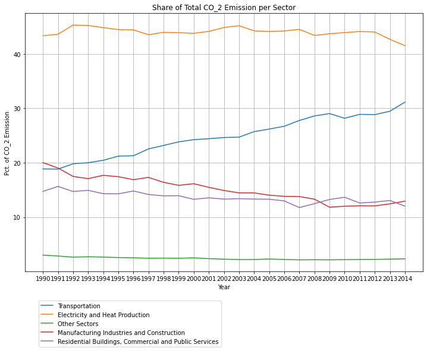

```python
#setting graph size
fig = plt.gcf()
fig.set_size_inches(12,8)
# Ref.: https://stackoverflow.com/questions/332289/how-do-you-change-the-size-of-figures-drawn-with-matplotlib

#assigning a color to each dataset
colors={'trans':'tab:blue', 'elect':'tab:orange', 'other':'tab:green', \
        'manuf':'tab:red', 'build':'tab:purple', 'co2':'tab:cyan', 'ghg':'lawngreen'}

sectorNames={'trans':'Transportation', 'elect':'Electricity and Heat Production', \
             'other':'Other Sectors', 'manuf':'Manufacturing Industries and Construction', \
             'build':'Residential Buildings, Commercial and Public Services', \
             'co2':'CO_2 Emission (kt)', 'ghg':'Greenhouse Gas Emissions (kt)'}

for i in range (len(DS)-2):
    dfName=list(DS.items())[i][0]
    plt.plot(list(DS.items())[i][1].mean(), label=sectorNames[dfName], color=colors[dfName]);
plt.title('Share of Total CO_2 Emission per Sector')
plt.legend(loc='best', bbox_to_anchor=(0.5, -0.1))
plt.xlabel('Year')
plt.ylabel('Pct. of CO_2 Emission')
plt.grid(True)
plt.show()

#Ref.s: https://stackoverflow.com/questions/23556153/how-to-put-legend-outside-the-plot-with-pandas
#       https://matplotlib.org/3.1.0/api/_as_gen/matplotlib.pyplot.legend.html
```

At first sight, we can see that the sector of electricity and heating has the highest share of $CO_2$ producition from fossil fuels, followed by transport, manufactring services, building and other services.

While transport and manufacturing show a clear trend (upward and downward, respectively), the trend is not completely clear for the other sectors.

Therefore, we will look now at each dataset singularly and explore its boxplots.

#### 3.1.1 Transport Sector

- Mean Trend

```python
def showPlot(dfName, external_df=None, colour=None, xLabel='', yLabel=''):
    fig=plt.gcf()
    fig.set_size_inches(12,5)
    if external_df is None:
        plt.plot(DS[dfName].mean(), label=sectorNames[dfName], color=colors[dfName]);
        plt.title('Share of Total CO_2 Emission of Sector ' + sectorNames[dfName])
        plt.xlabel('Year')
        plt.ylabel('Pct. of CO_2 Emission')
        plt.legend(loc='best', bbox_to_anchor=(0.2, -0.1))
    else:
        if colour is None:
            plt.plot(external_df, label=dfName);
        else:
            plt.plot(external_df, label=dfName, color=colour);
        plt.title(dfName)
        plt.xlabel(xLabel)
        plt.ylabel(yLabel)
        plt.legend(loc='best', bbox_to_anchor=(0.5, -0.15))
    plt.grid(True)
```

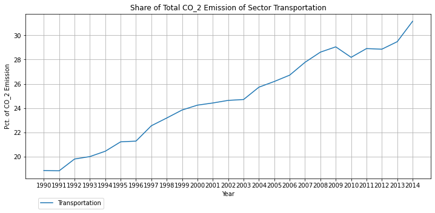

```python
showPlot('trans')
```

```python
DS['trans'].mean().describe()
```

```
count    25.000000
mean     24.748257
std       3.685244
min      18.843214
25%      21.287143
50%      24.637857
75%      28.182143
max      31.146429
dtype: float64
```

The percentage of $CO_2$ produciton from fossil fuels in the EU transportation sector has increased on average from about 19% in the first years, to over 31% in 2014.

The mean shows a clear and constant upward trend (on average).

- Box-Plot

```python
def showBoxPlot(dfName):
    DS[dfName].plot(kind='box',
                    color=dict(boxes=colors[dfName], whiskers=colors[dfName], \
                               medians='r', caps=colors[dfName]),
                    showfliers=False, grid=True, rot=0, figsize=(12, 5))
    plt.title('Share of Total CO_2 Emission of Sector ' + sectorNames[dfName])
    plt.xlabel('Year')
    plt.ylabel('Pct. of CO_2 Emission')

#Ref.s: https://stackoverflow.com/questions/35160956/pandas-boxplot-set-color-and-properties-for-box-median-mean
#       https://matplotlib.org/api/_as_gen/matplotlib.pyplot.boxplot.html#matplotlib.pyplot.boxplot
```

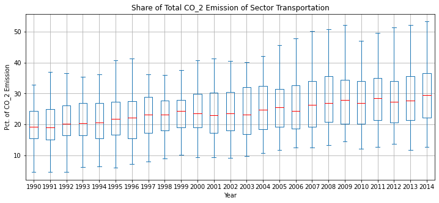

```python
showBoxPlot('trans')
```

By looking at the boxplots, we can see that the percentage of $CO_2$ emission from the transportation sector in the EU has risen from below 20% in 1990 to about 30% in 2014.

Considering the median, there is a clear upward trend, even though the rise was non-monotonic.

For each boxplot element (min, Q1, median, Q3, max), the increase looks greater, the greater the element order

I.e., $\Delta_{min} < \Delta_{Q1} < \Delta_{median} < \Delta_{Q3} < \Delta_{max}$

Outlayers appear from the second third of the dataset on.

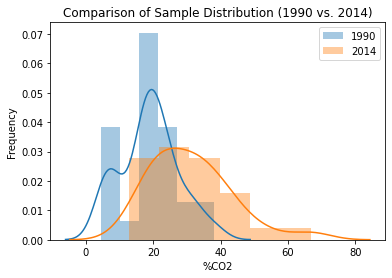

```python
fig2 = sns.distplot(DS['trans']['1990'], label='1990');
fig2 = sns.distplot(DS['trans']['2014'], label='2014');
plt.legend();
plt.title('Comparison of Sample Distribution (1990 vs. 2014)')
fig2.set_xlabel('%CO2');
fig2.set_ylabel('Frequency');
```

```python
DS['trans']['1990'].kurtosis()
```

```
-0.19867815942892886
```

```python
DS['trans']['2014'].kurtosis()
```

```
1.395747219970537
```

The kurtosis is greater for 2014 than for 1990. This empirically quantifies our 'fat tail' assessment from the distribution graph.

Taken together, these findings are more consistent with an hypothesis of exponential growth, rather than one of constant, upward trend - as mentioned above.

To proceed futher, we could assess whether this is consistent with sample variability and compare the fit of a linear model with the fit of an exponential one - for instance.

Nevertheless, we will not explore this issue further, for it lays out of the scope of this project.

#### 3.1.2. Electricity and Heat Production

- Mean Trend

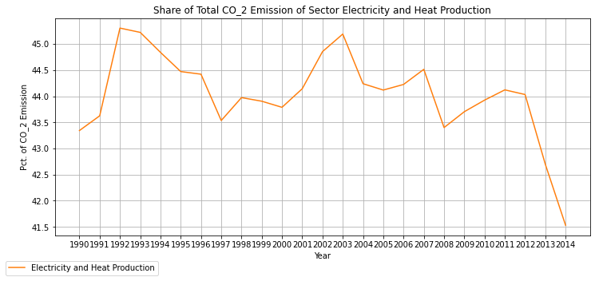

```python
showPlot('elect')
```

```python
DS['elect'].mean().describe()
```

```
count    25.000000
mean     44.044586
std       0.814312
min      41.529286
25%      43.703571
50%      44.117857
75%      44.471429
max      45.303571
dtype: float64
```

```python
DS['elect'].loc[:, :'2012'].mean().describe()
```

```
count    23.000000
mean     44.212593
std       0.568855
min      43.342857
25%      43.845893
50%      44.121429
75%      44.492857
max      45.303571
dtype: float64
```

The mean trend of the percentage of $CO_2$ emission from electricity and heat production in the EU has been constantly around 44.2% up to 2012 an has dropped thereafter of about 2.7%, to 41.5%.

- Box-Plot

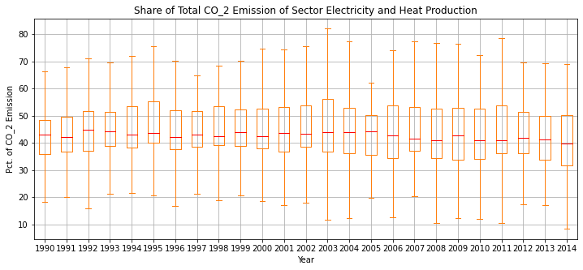

```python
showBoxPlot('elect')
```

By looking at the boxplots, the sample distribution has been basically constant.

In the last five years, the median has fluctuated more closely to .4 than in the past years - where it has been mostly well above.

The sample distrbution range widened more in more recent years, with some exceptions like in 1997 and 2005. The same trend has been followed by the 50% of observations between Q3 and Q1.

Outlayers appear in almost all years. They are more frequent in the first half of the plot. Lower outliers are more concentrated for years between 1993 and 2002.

#### 3.1.3 Manufacturing Industries and Construction

- Mean Trend

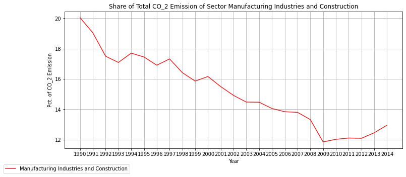

```python
showPlot('manuf')
```

```python
DS['manuf'].mean().describe()
```

```
count    25.000000
mean     15.169191
std       2.341627
min      11.844643
25%      13.319643
50%      14.911429
75%      17.084286
max      20.035714
dtype: float64
```

The percentage of $CO_2$ emission for manufacturing and construction industries in the EU experienced a downward trend.

In more recent years (from 2003 onwards), the curve flattens. Starting from 2009 (lowest observation), the curve seems inverting the trend.

Nevertheless, this effect may be due to sampling variability - meaning, there may have been exogenous factors (e.g. great recession) that have biased the observation from the underlying trend.

- Box-Plot

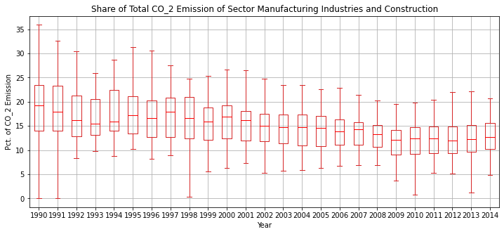

```python
showBoxPlot('manuf')
```

The boxplots replicate the same trend that we have seen above.

Considering the median, it droped from about 20% in 1990 to about 13% in 2014.

This trend is visible in almost all boxplot elements (Q1, median, Q3, max), while it is more pronounced for the upper ones (Q3, max).

Outlayers are constantly appearing in the lower part of the graph. In the upper part, they are more concentrated in early years.

Generally, this graph suggest a progressive concentration of observations along the median trend - meaning that the trend has been followed by the most EU countries, resulting in a kind of "convergence".

#### 3.1.4 Residential Buildings and Commercial and Public Services

- Mean Trend

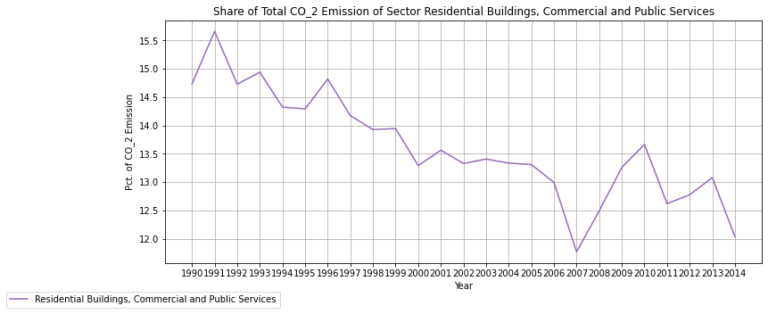

```python
showPlot('build')
```

```python
DS['build'].mean().describe()
```

```
count    25.000000
mean     13.617271
std       0.944944
min      11.767857
25%      13.077143
50%      13.405000
75%      14.291429
max      15.659286
dtype: float64
```

The percentage of $CO_2$ emission for residential buildings, commercial and public services followed a downward trend. However, this trend does not look so marked as for the previous dataset.

- Box-Plot

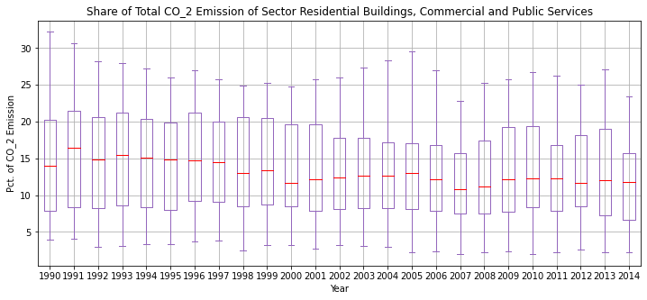

```python
showBoxPlot('build')
```

By looking at the boxplots, a weak downward trend is observed.

The median values dropped from about 15% in early years to about 12% in more recent years.

The observations maintain more or less the same boxplot proportions in every year.

Considering the boxplot elements (min, Q1, median, Q3, max), the decrease looks more pronounced for max and Q3 values. These elements are subjected to greater volatility as well.

Outlayers are absent.

Generally, the distribution remained mainly constant, with a slight drop in mass of the top 50% observations ("upper" part of the plot).

#### 3.1.5 Other Sectors

- Mean Tend

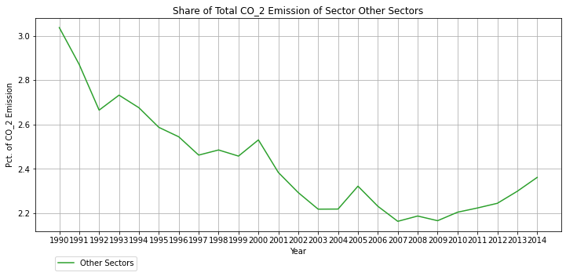

```python
showPlot('other')
```

```python
DS['other'].mean().describe()
```

```
count    25.000000
mean      2.422045
std       0.235578
min       2.162854
25%       2.223021
50%       2.360961
75%       2.544000
max       3.036571
dtype: float64
```

```python
DS['other']['2014'].mean()
```

```
2.3609607142857145
```

```python
DS['other']['2007'].mean()
```

```
2.1628535714285713
```

By looking at the mean per year, the percentage of $CO_2$ production from other sectors dropped of about 0.68%, from 3.04% to 2.36%. The mean series reached a minimum of 2.16% in 2007 and recovered slightly thereafter.

- Box-Plot

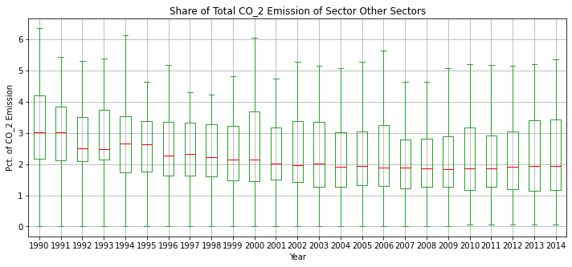

```python
showBoxPlot('other')
```

The boxplots highlight a slight downward trend as well.

The median values dropped about 1%, from 3% to about 2%.

Considering the boxplot elements (min, Q1, median, Q3, max), the trend is more pronounced for Q1 and median, whereas Q3 and max values are subjected to higher volatility.

Outlayers are concentrated between years 1993 and 2001.

Generally, the sample distribution remained mainly constant, with higher volatility for max and Q3 values.

## 4 Assessment of the Claims

### 4.1 Claim1 - Transport is Europe's biggest source of $CO_2$

Just by looking at the graph of the mean-trend in § 3.1, we can tell that transportation is not the biggest source of $CO_2$ emission in the EU.

The mean percentage of CO2 emission for the transportation sector within the EU in 2014 is:

```python
float("{:.2f}".format(DS['trans']['2014'].mean()))

#Ref.: https://kite.com/python/answers/how-to-print-a-float-with-two-decimal-places-in-python
```

```
31.15
```

This is also the highest value of the series.

In comparison to the other sectors, 'electricity and heat production' has a larger share than 'transportation'.

```python
[(df[0], float("{:.2f}".format(df[1]['2014'].mean()))) for df in list(DS.items())[:-2]]
```

```
[('trans', 31.15),
 ('elect', 41.53),
 ('other', 2.36),
 ('manuf', 12.95),
 ('build', 12.03)]
```

Let us check that the total sums up to 100.

```python
mean_values=[df[1]['2014'].mean() for df in list(DS.items())[:-2]]
np.array(mean_values).dot(np.ones(len(mean_values)))
```

```
100.02346071428572
```

#### Answer:

No. The transportation sector is not the biggest source of $CO_2$ in Europe.

### 4.2 Claim 2 - Transport emissions have increased by a quarter since 1990

Let us take a look at the mean trend of $CO_2$ emissions.

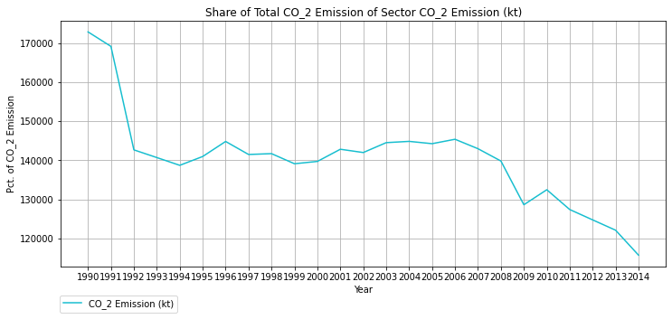

```python
showPlot('co2')
```

Overall in the EU, $CO_2$ emissions have dropped from 1990 onwards. After a stabile period from 1992 to 2006, the series shows a decreasing trend.

Given that the share of $CO_2$ emissions for the transportation sector increased constantly in the same period of time, we cannot tell now whether this increase in share is sufficient in order to revert the trend shown here above, or not.

We can now extract the share of $CO_2$ emissions from the transportation sector between 1990 and 2014.

In doing so, we

1. calculate the mean,
2. transform the share format into decimal values,
3. create a named copy of the resulting series.

```python
transportation_share=DS['trans'].mean().apply(lambda x: x/100).copy()
```

```python
transportation_share
```

```
1990    0.188682
1991    0.188432
1992    0.198125
1993    0.200136
1994    0.204532
1995    0.212268
1996    0.212871
1997    0.225507
1998    0.231875
1999    0.238464
2000    0.242461
2001    0.244243
2002    0.246379
2003    0.247089
2004    0.257250
2005    0.261929
2006    0.267143
2007    0.277714
2008    0.286071
2009    0.290429
2010    0.281821
2011    0.289000
2012    0.288500
2013    0.294679
2014    0.311464
dtype: float64
```

Then we can sum up $CO_2$ emissions. In doing so, we will drop the 'country' column and create a named copy of the series.

```python
co2_emissions=DS['co2'].sum().drop('country').copy()
```

```python
co2_emissions
```

```
1990    4.83925e+06
1991    4.73544e+06
1992     3.9949e+06
1993     3.9399e+06
1994    3.88436e+06
1995    3.94746e+06
1996    4.05507e+06
1997    3.96198e+06
1998    3.96788e+06
1999     3.8957e+06
2000    3.91218e+06
2001    3.99933e+06
2002    3.97585e+06
2003     4.0466e+06
2004     4.0557e+06
2005    4.03921e+06
2006    4.07067e+06
2007    4.00324e+06
2008    3.91514e+06
2009    3.60224e+06
2010    3.70964e+06
2011    3.56796e+06
2012    3.49386e+06
2013    3.41997e+06
2014    3.24144e+06
dtype: object
```

Short check of data types:

```python
type(co2_emissions[0])
```

```
float
```

```python
co2_emissions.describe()
```

```
count          25.0
unique         25.0
top       4039210.0
freq            1.0
dtype: float64
```

We can now multiply the two series row by row, an plot the graph.

```python
transportation_emissions=co2_emissions.mul(transportation_share, axis=0)

#Ref.: https://stackoverflow.com/questions/13166842/pandas-dataframe-multiply-with-a-series
```

```python
transportation_emissions
```

```
1990         913080
1991         892309
1992         791490
1993         788515
1994         794476
1995         837919
1996         863209
1997         893455
1998         920052
1999         928985
2000         948550
2001         976808
2002         979564
2003         999872
2004    1.04333e+06
2005    1.05798e+06
2006    1.08745e+06
2007    1.11176e+06
2008    1.12001e+06
2009    1.04619e+06
2010    1.04546e+06
2011    1.03114e+06
2012    1.00798e+06
2013    1.00779e+06
2014    1.00959e+06
dtype: object
```

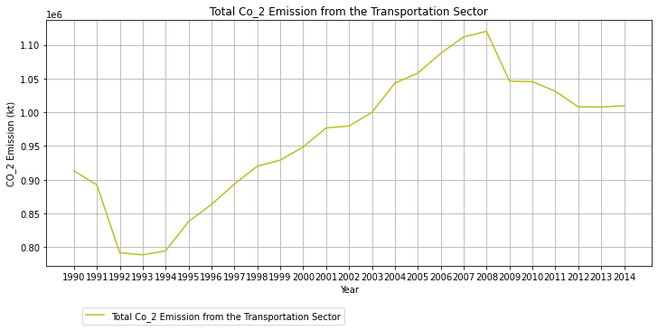

```python
showPlot('Total Co_2 Emission from the Transportation Sector', \
         external_df=transportation_emissions, colour='tab:olive', \
         xLabel='Year', yLabel='CO_2 Emission (kt)')
```

Indeed and after an initial drop, the $CO_2$ emissions from the transportation sector have increased constantly from 1993 onwards, reachng a peak in 2008, and dropping slightly thereafter.

We can now answer our qustion, by computing the percentual increase.

```python
transportation_emissions['2014']/transportation_emissions['1990'] - 1
```

```
0.10569980771837129
```

#### Answer:

On the basis of Gapminder's data, the emission of $CO_2$ from the transportation sector have increased by 10.57 % from 1990 within EU countries. The claim of an inrease of 25% does not find empirical evidence.

Nevertheless, we have to consider that our series contains records up to 2014 only, and we have restricted our analysis just to EU countries.

### 4.3 Claim 3 - Transport is responsible for the emission of over a quarter of all greenhouse gases

- mean trend of greeenhouse gas emissions

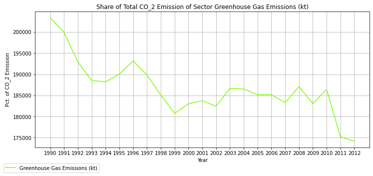

```python
showPlot('ghg')
```

On average, the greenhouse gas emissions have followed a downward trend. Reduction was more saharp from 1991 to 1999. Thereafter, emissions rose slowly up to 2010 and drop sharply in 2011. The series' minimum is reached in 2012, our last year of observation.

We will now sum up the greenhouse gas emissions per year, trim the resulting series by removing non-matching years, and calculate the share of greenhouse gas emissions for the transportation sector.

```python
greenhouse_emissions=DS['ghg'].sum().drop('country').copy()
```

```python
greenhouse_emissions
```

```
1990    5.69584e+06
1991    5.59701e+06
1992    5.40073e+06
1993    5.27908e+06
1994    5.27041e+06
1995     5.3219e+06
1996    5.40859e+06
1997    5.31544e+06
1998    5.18233e+06
1999    5.06173e+06
2000     5.1247e+06
2001    5.14524e+06
2002    5.10849e+06
2003    5.22696e+06
2004    5.22255e+06
2005    5.18508e+06
2006    5.18522e+06
2007    5.13291e+06
2008    5.23918e+06
2009    5.12497e+06
2010    5.22049e+06
2011    4.90544e+06
2012    4.87753e+06
dtype: object
```

Short check of data types:

```python
type(greenhouse_emissions[0])
```

```
float
```

```python
greenhouse_emissions.describe()
```

```
count          23.0
unique         23.0
top       5185080.0
freq            1.0
dtype: float64
```

We can drop non-matching years from the transportation emissions series.

```python
transportation_emissions.drop(['2013', '2014'], inplace=True)
```

```python
transportation_emissions
```

```
1990         913080
1991         892309
1992         791490
1993         788515
1994         794476
1995         837919
1996         863209
1997         893455
1998         920052
1999         928985
2000         948550
2001         976808
2002         979564
2003         999872
2004    1.04333e+06
2005    1.05798e+06
2006    1.08745e+06
2007    1.11176e+06
2008    1.12001e+06
2009    1.04619e+06
2010    1.04546e+06
2011    1.03114e+06
2012    1.00798e+06
dtype: object
```

As for transportation emission, we can use a similar function, 'div' in order to divide the series row by row.

```python
transportation_share_ghg=transportation_emissions.div(greenhouse_emissions, axis=0)

#Ref.: https://pandas.pydata.org/pandas-docs/stable/reference/api/pandas.DataFrame.div.html
```

```python
transportation_share_ghg
```

```
1990    0.160307
1991    0.159426
1992    0.146552
1993    0.149366
1994    0.150743
1995    0.157447
1996      0.1596
1997    0.168087
1998    0.177536
1999    0.183531
2000    0.185094
2001    0.189847
2002    0.191752
2003    0.191291
2004    0.199774
2005    0.204044
2006    0.209721
2007    0.216594
2008    0.213776
2009    0.204137
2010     0.20026
2011    0.210203
2012    0.206658
dtype: object
```

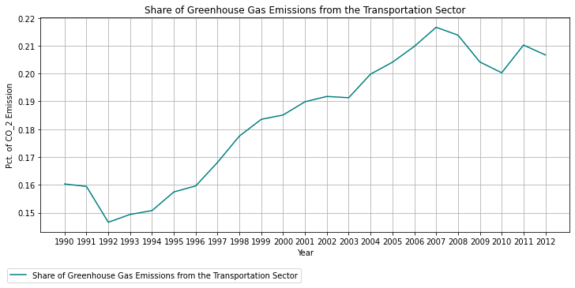

```python
showPlot('Share of Greenhouse Gas Emissions from the Transportation Sector', \
         external_df=transportation_share_ghg, colour='teal', \
         xLabel='Year', yLabel='Pct. of CO_2 Emission')
```

```python
transportation_share_ghg.max()
```

```
0.21659388867968796
```

#### Answer:

Given Gapminder's data and limiting our analysis to EU countries, we can state that the transportation sector is responsible for about 20% of the greenhouse gas emissions in 2012 - our last year of reference.

The claimed value of >25% does not find evidence from these data.

Nevertheless, we have just considered $CO_2$ emissions from fossil fuels for the transportation sector. I.e. we are not considering the emission of other greenhouse gases that are originated from fuel combustion, like methane ($CH_4$), nitrous oxide ($N_2O$) or hydrofluorocarbon ([reference 1](https://www.epa.gov/ghgemissions/sources-greenhouse-gas-emissions#transportation)). This means that the greenhouse gas emissions from the transportation sector are underestimated.

Indeed, if the share of methane and nitrous oxide in the transportation sector were closed to (or above) their overall greenhouse-gas emissions share (respectively 10% and 7%, [reference 2](https://www.epa.gov/ghgemissions/overview-greenhouse-gases)), we could not exclude that the transportation share of greenhouse gas emissions may reach (or exceed) 25%.

Morever, we have to consider that the series trend may have been maintained in more recent years as well.

Overall, we can conclude that claim 3 may be consistent with Gapminder's data, for they are not sufficient alone to perform an exhaustive anlysis.

## 5 Conclusions

By making use of Gapminder's datasets, we have assessed few statements contained in the report "$CO_2$ Emissions from Cars: the facts" of the European Federation for Transport and Environment AISBL.

In particular:

- **Claim 1** - *Transport is Europe's biggest source of CO_2*;
- **Claim 2** - *Transport emissions have increased by a quarter since 1990*;
- **Claim 3** - *Transport is responsible for the emission of over a quarter of all greenhouse gases*.

The datasets used concerned the shares of $CO_2$ emission per industry sector, the total of $CO_2$ and greenhouse gas emissions. We have limited our analysis to EU counries and considered a time range from 1990 to 2014 (2012 for the greenhouse gas emissions).

After data preparation, we inspected each dataset's mean trend and boxplots. Then, we have assessed the report claims.

### 5.1 Results

- **General Results**

We have found out that, in 2014, the sector of electricity and heating has had the highest share of $CO_2$ producition from fossil fuels, followed by transport, manufactring services, building and other services.

The transportation sector registered the highest increase in share (from an inital 19%, to over 31% in 2014), wherease manufacturing the highest decrease (from 20% to about 13%). The other secors recorded overall slight decreases from their respective 1990 values.

- **Report Claims**

By looking at Gapminder's data on $CO_2$ production share by sector, we can affirm that transportation is not the biggest source of CO2 emission in the EU.

Concerning Claim 2, we have seen that even though the $CO_2$ emissions have overall dropped from 1990 onwards, those originated from the transportation sector have indeed increased. However, the overall increase was equal to 10.57% and not 25%.

When taking the greenhouse-gas $CO_2$-equivalent emissions into account, the claimed value of more than 25% of greenhouse gas emissions coming from the transportation sector does not find evidence from these data, at first. The maximum share value is 21.66%.

### 5.2 Limitations

Generally, the Gapminder's datasets that we have used provide records up to year 2014 (2012 for Greenhouse gas emissions), wherease all report's claims have been made in 2018. Of course, the lack of more-recent data possibly biases our analysis.

Nevertheless and regarding Claim 1, the difference between the share of energy and heating and the share of transportation is very high (about 10% in 2014). It is unlikely that this gap has been closed in 3 (or even in 4) years. Indeed and as an indication, some online sources show that there is still a gap in 2016 ([reference 3](https://www.statista.com/statistics/206115/total-oecd-europe-carbon-dioxide-emissions-by-sector/)).

Concernig Claim 3, we have pointed out that the amount of greenhouse gas emissions from the transportation sector are likely underestimated, for other greenhouse gases from fuel combustion are not taken into account, like methane ($CH_4$), nitrous oxide ($N_2O$) or hydrofluorocarbon.

Furthermore, we have to consider that the share of $CO_2$ from the transportation sector may have increased further in more recent years as well.

Therefore, we cannot empirically refute 'claim 3', for Gapminder's data are not sufficient alone to perform an exhaustive anlysis.

<sup>1</sup> If the document is not available online, a copy has been provided among the files submitted - file name: '0-2018_04_CO2_emissions_cars_The_facts_report_final_0_0.pdf'.